# Homework 7 Solutions

STAT 757 – Section 1001  
Instructor: Colin Grudzien

## Due: 11/07/2019

## Instructions

> You may work with others on these problems but you must turn in your own work.  
> You may type your solutions in any way you like (LaTeX, Markdown, Office, etc…) as long as you present your work clearly and in an organized way.  
> **Whenever plotting:**
> - Include a copy of a short R script corresponding to your plot.
> - Your plot must be clearly labeled in all axes, legends, and the plot must include a clear title.
> - The plot must be sensible and easy to read.

## Problems

### Load the library “Faraway” in the R environment. Then proceed to analyze the following data sets in this library:

```r
library(MASS)
library(faraway)
library(leaps)
```

### Problem 1:

Using the `ozone` data, fit a model with `O3` as the response and `temp`, `humidity` and `ibh` as predictors. Use the Box–Cox method to determine the best transformation on the response.

#### Solution:

We will fit a model with `O3` as the response, and `temp`, `humidity` and `ibh` as predictors. We have,

```r
lmod <- lm(O3 ~ temp + humidity + ibh, data=ozone)
summary(lmod)
```

```
##
## Call:
## lm(formula = O3 ~ temp + humidity + ibh, data = ozone)
##
## Residuals:
##      Min       1Q   Median       3Q      Max
## -11.5291  -3.0137  -0.2249   2.8239  13.9303
##
## Coefficients:
##               Estimate Std. Error t value Pr(>|t|)
## (Intercept) -1.049e+01  1.616e+00  -6.492 3.16e-10 ***
## temp         3.296e-01  2.109e-02  15.626  < 2e-16 ***
## humidity     7.738e-02  1.339e-02   5.777 1.77e-08 ***
## ibh         -1.004e-03  1.639e-04  -6.130 2.54e-09 ***
## ---
## Signif. codes:  0 '***' 0.001 '**' 0.01 '*' 0.05 '.' 0.1 ' ' 1
##
## Residual standard error: 4.524 on 326 degrees of freedom
## Multiple R-squared:  0.684,  Adjusted R-squared:  0.6811
## F-statistic: 235.2 on 3 and 326 DF,  p-value: < 2.2e-16
```

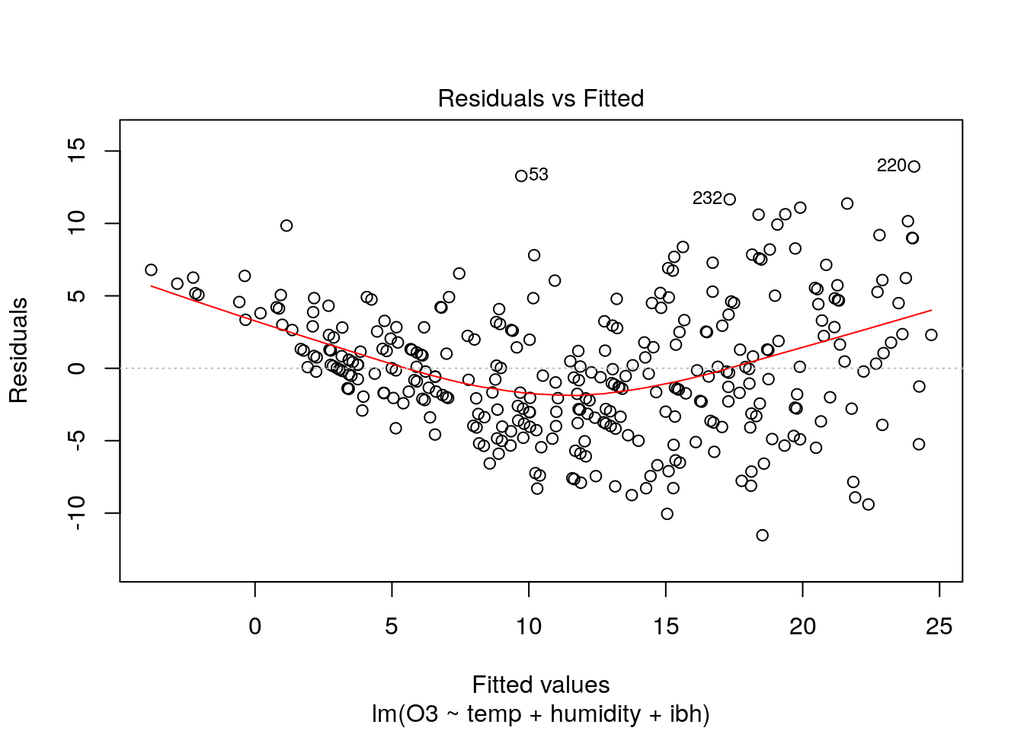

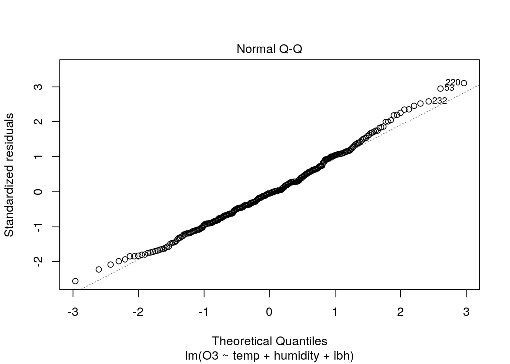

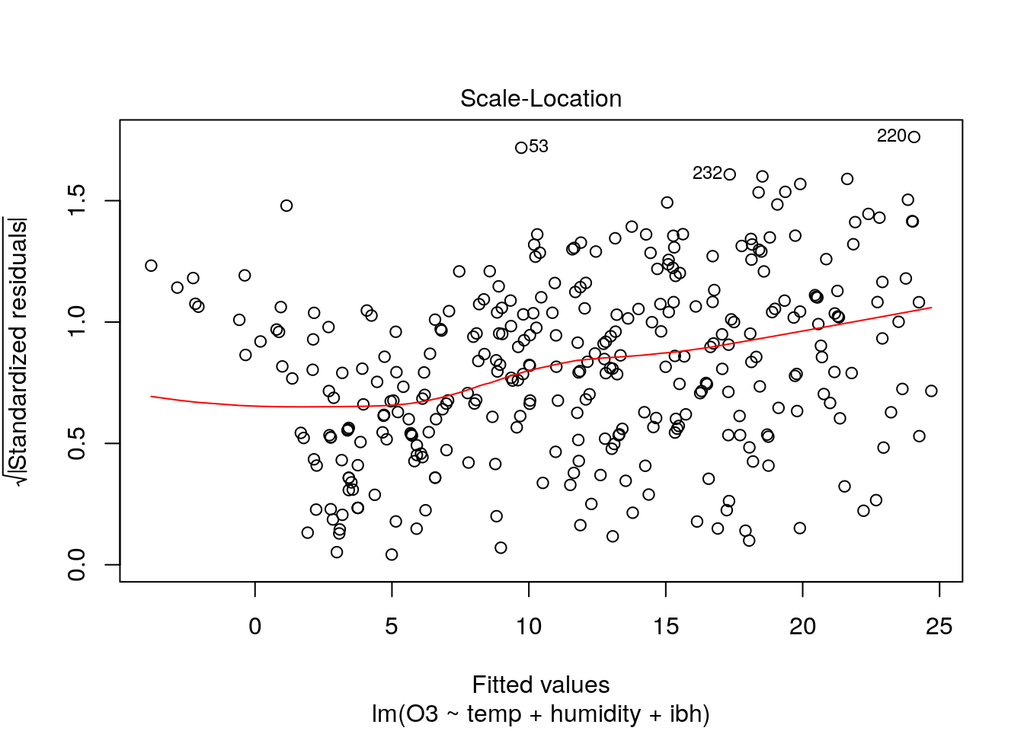

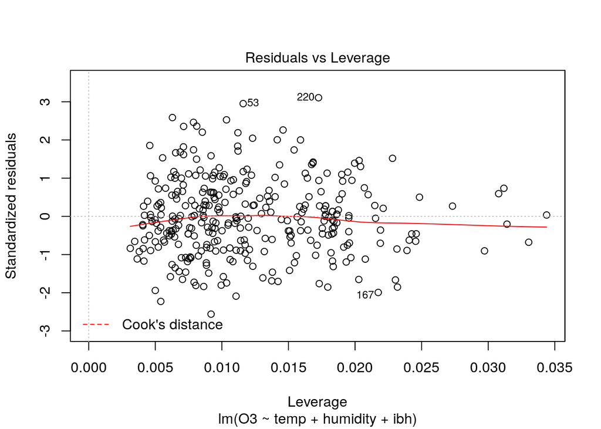

```r
plot(lmod)
```

We notice that there is strong indications of non-constant variance of the error and nonlinear structure in the residuals. We will perform a Box-Cox transformation on the response “O3” to see if this eliminates the issues.

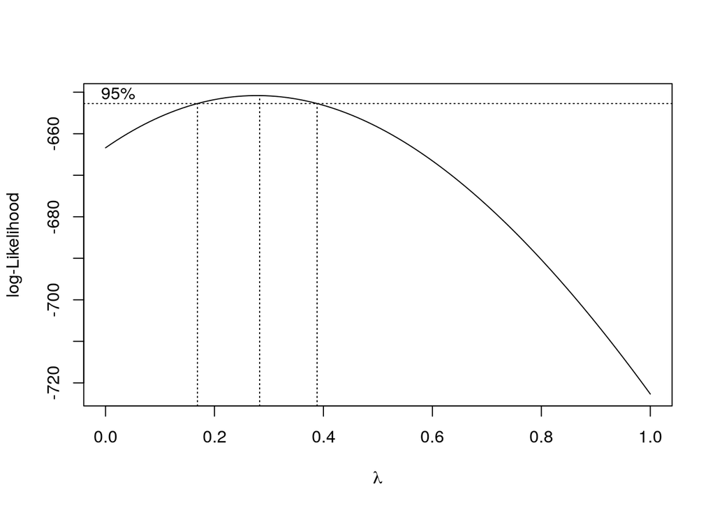

```r
boxcox(lmod, plotit=T, lambda=seq(0,1,by=0.1))
```

With respect to the Box-Cox $95\%$ condidence interval, we see that the transformation by $y\mapsto y^{1/4}$ or $y\mapsto y^{1/3}$ are both plausible values for a transformation, and we securely rule out the null mapping.

We compare thus the transformation by the quartic and cubic roots:

```r
lmod <- lm(O3^(1/4) ~ temp + humidity + ibh, data=ozone)
summary(lmod)
```

```
##
## Call:
## lm(formula = O3^(1/4) ~ temp + humidity + ibh, data = ozone)
##
## Residuals:
##     Min      1Q  Median      3Q     Max
## -0.5433 -0.1084  0.0091  0.1247  0.4933
##
## Coefficients:
##               Estimate Std. Error t value Pr(>|t|)
## (Intercept)  9.137e-01  6.184e-02  14.774  < 2e-16 ***
## temp         1.307e-02  8.070e-04  16.192  < 2e-16 ***
## humidity     2.977e-03  5.124e-04   5.810 1.48e-08 ***
## ibh         -4.849e-05  6.269e-06  -7.734 1.31e-13 ***
## ---
## Signif. codes:  0 '***' 0.001 '**' 0.01 '*' 0.05 '.' 0.1 ' ' 1
##
## Residual standard error: 0.1731 on 326 degrees of freedom
## Multiple R-squared:  0.7152, Adjusted R-squared:  0.7126
## F-statistic: 272.9 on 3 and 326 DF,  p-value: < 2.2e-16
```

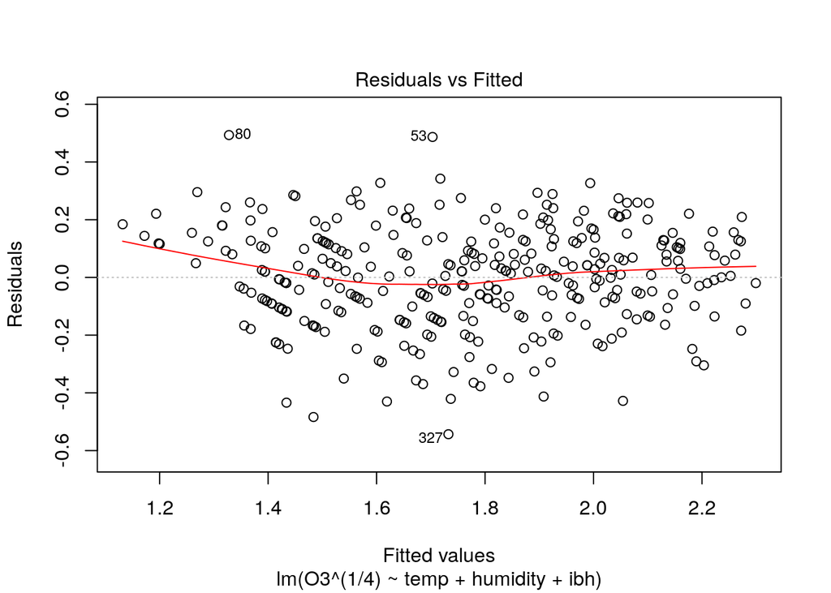

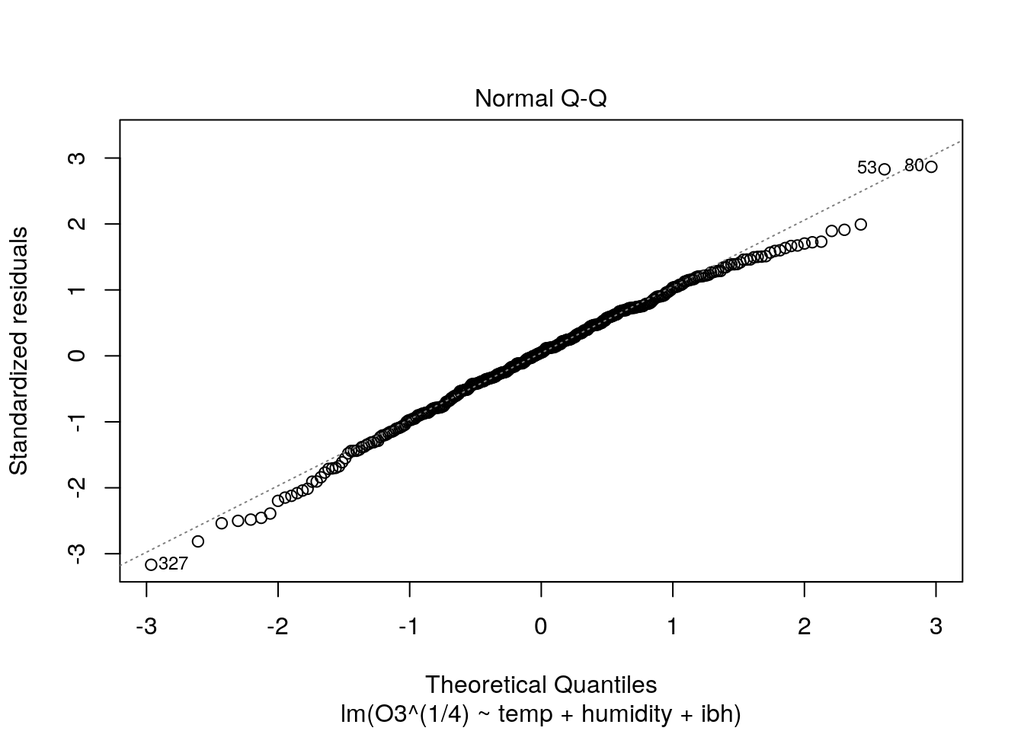

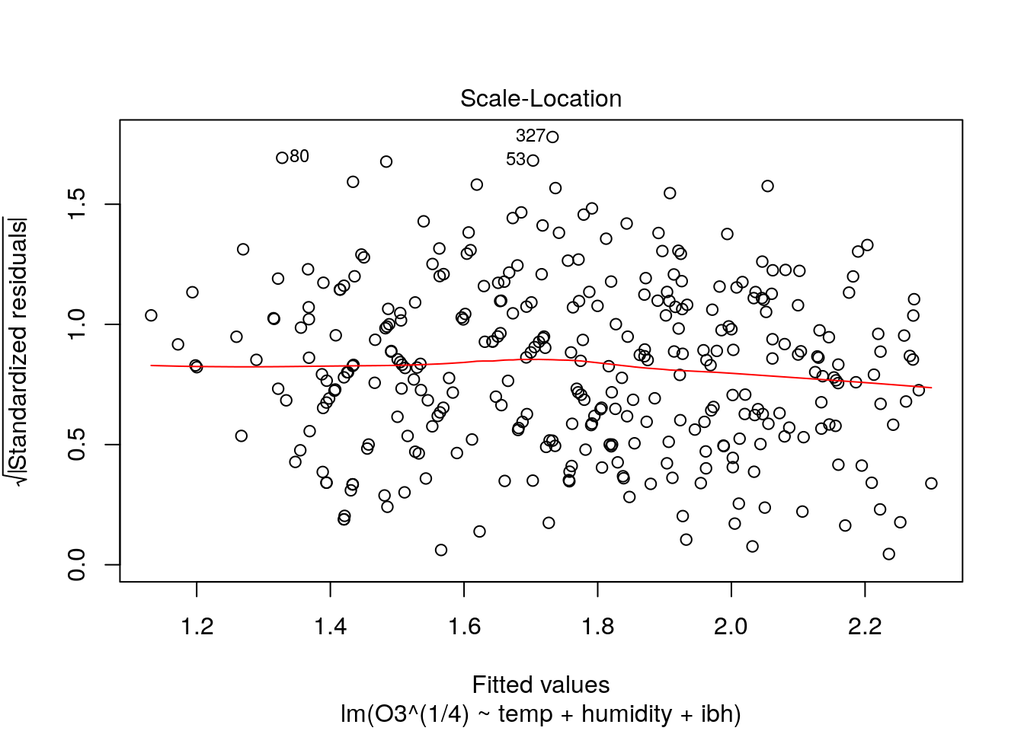

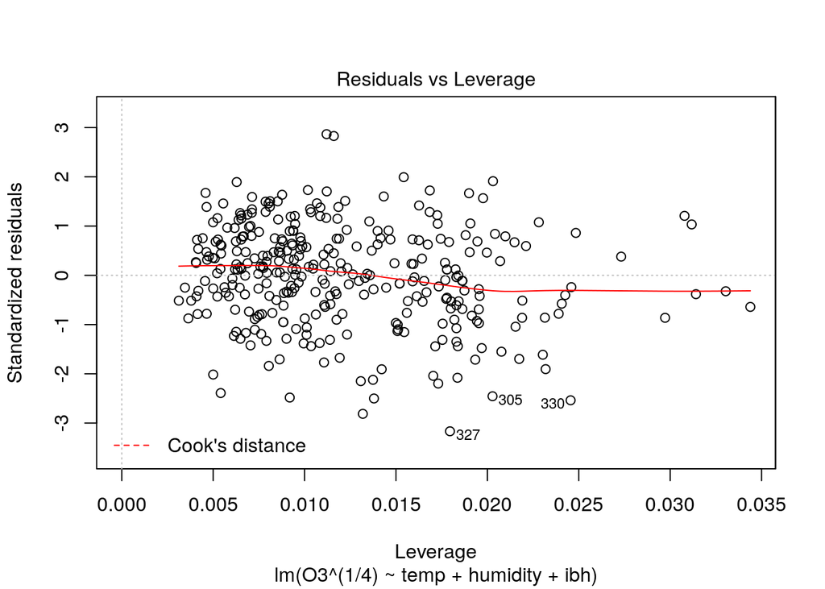

```r
plot(lmod)
```

```r
lmod <- lm(O3^(1/3) ~ temp + humidity + ibh, data=ozone)
summary(lmod)
```

```
##
## Call:
## lm(formula = O3^(1/3) ~ temp + humidity + ibh, data = ozone)
##
## Residuals:
##      Min       1Q   Median       3Q      Max
## -0.83199 -0.16870  0.01175  0.19914  0.79844
##
## Coefficients:
##               Estimate Std. Error t value Pr(>|t|)
## (Intercept)  7.625e-01  9.926e-02   7.682 1.85e-13 ***
## temp         2.116e-02  1.295e-03  16.338  < 2e-16 ***
## humidity     4.879e-03  8.225e-04   5.933 7.61e-09 ***
## ibh         -7.693e-05  1.006e-05  -7.645 2.36e-13 ***
## ---
## Signif. codes:  0 '***' 0.001 '**' 0.01 '*' 0.05 '.' 0.1 ' ' 1
##
## Residual standard error: 0.2778 on 326 degrees of freedom
## Multiple R-squared:  0.7175, Adjusted R-squared:  0.7149
## F-statistic:   276 on 3 and 326 DF,  p-value: < 2.2e-16
```

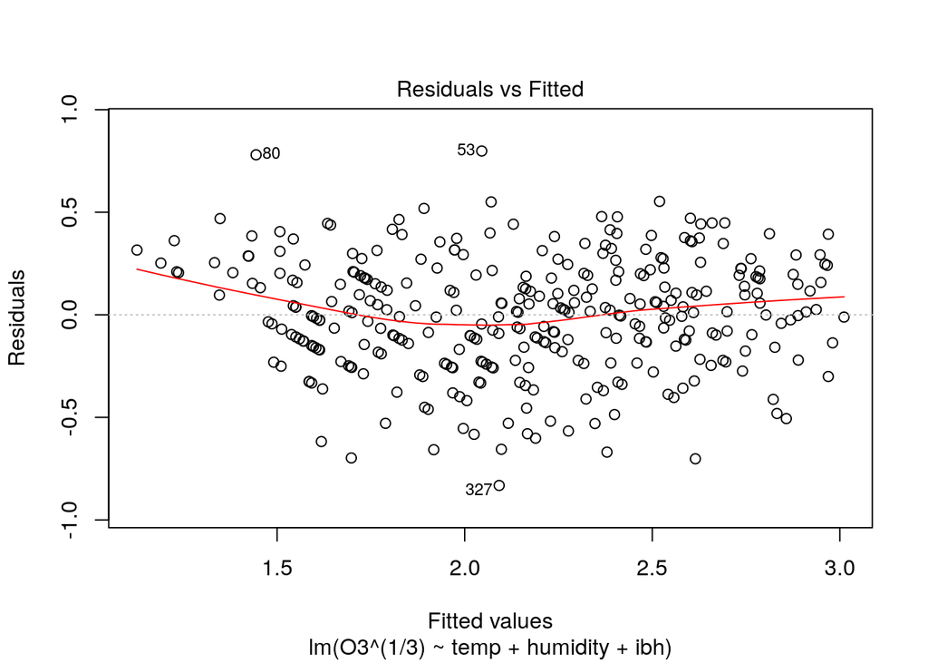

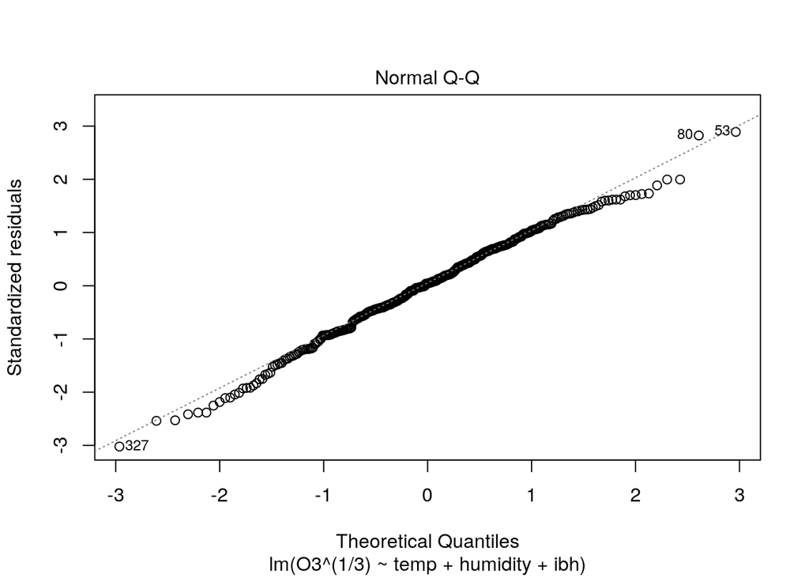

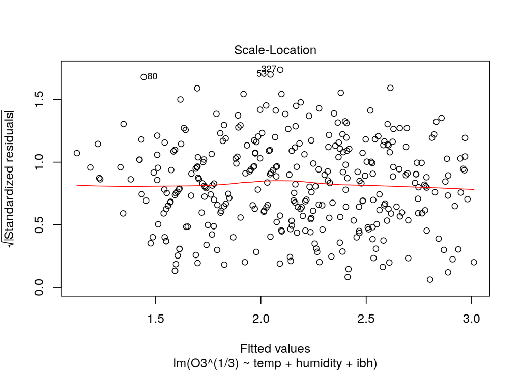

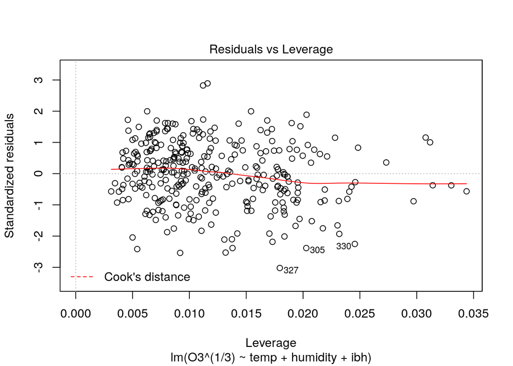

```r
plot(lmod)
```

As both transformations appear to deal with the nonlinearity in the residuals and the non-constant variance, both seem appropriate. We might favor the quartic root due to the lower standard error, but the difference overall is negligible.

### Problem 2:

Using the `fat` dataset, fit a model with `brozek` as the response and `age`, `weight`, `height` and the body circumfrence measurements as predictors. Then simplify the saturated model using each of:

1. Backward eliminaton
2. AIC
3. Adjusted $R^2$
4. Mallow’s $C_p$

as a criterion for model selection. Discuss the differences in the selected models (if any).

#### Solution:

We will select a model for the fat data using each of the below:

##### Backward selection:

Here we will fit the model with all explanatory variables and work our way backwards to a smaller model with an initial choice of $\alpha_\mathrm{crit}=5\%$:

```r
lmod <- lm(brozek ~ age + weight + neck + chest + abdom + hip + thigh + knee + ankle + biceps + forearm + wrist, data=fat)
summary(lmod)
```

```
##
## Call:
## lm(formula = brozek ~ age + weight + neck + chest + abdom + hip +
##     thigh + knee + ankle + biceps + forearm + wrist, data = fat)
##
## Residuals:
##      Min       1Q   Median       3Q      Max
## -10.2824  -2.6133  -0.1122   2.8625   9.3754
##
## Coefficients:
##               Estimate Std. Error t value Pr(>|t|)
## (Intercept) -22.148586  12.993408  -1.705  0.08957 .
## age           0.059682   0.029669   2.012  0.04539 *
## weight       -0.096652   0.044139  -2.190  0.02951 *
## neck         -0.433580   0.215052  -2.016  0.04490 *
## chest        -0.009308   0.089617  -0.104  0.91737
## abdom         0.891812   0.079515  11.216  < 2e-16 ***
## hip          -0.173632   0.130649  -1.329  0.18512
## thigh         0.251650   0.130794   1.924  0.05554 .
## knee         -0.025722   0.223087  -0.115  0.90830
## ankle         0.172755   0.204548   0.845  0.39920
## biceps        0.158480   0.158163   1.002  0.31736
## forearm       0.433311   0.184229   2.352  0.01948 *
## wrist        -1.512146   0.492601  -3.070  0.00239 **
## ---
## Signif. codes:  0 '***' 0.001 '**' 0.01 '*' 0.05 '.' 0.1 ' ' 1
##
## Residual standard error: 3.984 on 239 degrees of freedom
## Multiple R-squared:  0.7484, Adjusted R-squared:  0.7358
## F-statistic: 59.25 on 12 and 239 DF,  p-value: < 2.2e-16
```

Here, `chest` is the variable with the highest p-value greater than $\alpha_\mathrm{crit}$, so we remove this and repeat:

```r
lmod <- update(lmod, . ~ . - chest)
summary(lmod)
```

```
##
## Call:
## lm(formula = brozek ~ age + weight + neck + abdom + hip + thigh +
##     knee + ankle + biceps + forearm + wrist, data = fat)
##
## Residuals:
##      Min       1Q   Median       3Q      Max
## -10.2830  -2.6162  -0.1017   2.8789   9.3713
##
## Coefficients:
##              Estimate Std. Error t value Pr(>|t|)
## (Intercept) -22.66569   11.97691  -1.892  0.05963 .
## age           0.05948    0.02954   2.013  0.04521 *
## weight       -0.09829    0.04114  -2.389  0.01765 *
## neck         -0.43444    0.21445  -2.026  0.04389 *
## abdom         0.88762    0.06839  12.979  < 2e-16 ***
## hip          -0.17180    0.12919  -1.330  0.18483
## thigh         0.25327    0.12960   1.954  0.05183 .
## knee         -0.02318    0.22128  -0.105  0.91665
## ankle         0.17300    0.20411   0.848  0.39752
## biceps        0.15695    0.15715   0.999  0.31894
## forearm       0.43091    0.18239   2.363  0.01895 *
## wrist        -1.51011    0.49120  -3.074  0.00235 **
## ---
## Signif. codes:  0 '***' 0.001 '**' 0.01 '*' 0.05 '.' 0.1 ' ' 1
##
## Residual standard error: 3.976 on 240 degrees of freedom
## Multiple R-squared:  0.7484, Adjusted R-squared:  0.7369
## F-statistic:  64.9 on 11 and 240 DF,  p-value: < 2.2e-16
```

Next we remove `knee`

```r
lmod <- update(lmod, . ~ . - knee)
summary(lmod)
```

```
##
## Call:
## lm(formula = brozek ~ age + weight + neck + abdom + hip + thigh +
##     ankle + biceps + forearm + wrist, data = fat)
##
## Residuals:
##      Min       1Q   Median       3Q      Max
## -10.2552  -2.5979  -0.1133   2.8693   9.3584
##
## Coefficients:
##              Estimate Std. Error t value Pr(>|t|)
## (Intercept) -23.08716   11.25781  -2.051  0.04137 *
## age           0.05875    0.02864   2.051  0.04134 *
## weight       -0.09965    0.03897  -2.557  0.01117 *
## neck         -0.43088    0.21131  -2.039  0.04253 *
## abdom         0.88875    0.06740  13.186  < 2e-16 ***
## hip          -0.17231    0.12884  -1.337  0.18234
## thigh         0.24942    0.12403   2.011  0.04544 *
## ankle         0.16946    0.20089   0.844  0.39974
## biceps        0.15847    0.15616   1.015  0.31123
## forearm       0.42946    0.18150   2.366  0.01876 *
## wrist        -1.51470    0.48823  -3.102  0.00215 **
## ---
## Signif. codes:  0 '***' 0.001 '**' 0.01 '*' 0.05 '.' 0.1 ' ' 1
##
## Residual standard error: 3.968 on 241 degrees of freedom
## Multiple R-squared:  0.7484, Adjusted R-squared:  0.738
## F-statistic: 71.69 on 10 and 241 DF,  p-value: < 2.2e-16
```

Next we remove `ankle`

```r
lmod <- update(lmod, . ~ . - ankle)
summary(lmod)
```

```
##
## Call:
## lm(formula = brozek ~ age + weight + neck + abdom + hip + thigh +
##     biceps + forearm + wrist, data = fat)
##
## Residuals:
##      Min       1Q   Median       3Q      Max
## -10.0740  -2.5615  -0.1021   2.7999   9.3199
##
## Coefficients:
##              Estimate Std. Error t value Pr(>|t|)
## (Intercept) -20.61247   10.86240  -1.898   0.0589 .
## age           0.05727    0.02857   2.004   0.0461 *
## weight       -0.09141    0.03770  -2.424   0.0161 *
## neck         -0.45458    0.20931  -2.172   0.0308 *
## abdom         0.88098    0.06673  13.203   <2e-16 ***
## hip          -0.17575    0.12870  -1.366   0.1733
## thigh         0.25504    0.12378   2.061   0.0404 *
## biceps        0.15178    0.15587   0.974   0.3311
## forearm       0.42805    0.18138   2.360   0.0191 *
## wrist        -1.40948    0.47175  -2.988   0.0031 **
## ---
## Signif. codes:  0 '***' 0.001 '**' 0.01 '*' 0.05 '.' 0.1 ' ' 1
##
## Residual standard error: 3.965 on 242 degrees of freedom
## Multiple R-squared:  0.7477, Adjusted R-squared:  0.7383
## F-statistic: 79.67 on 9 and 242 DF,  p-value: < 2.2e-16
```

Next we remove `biceps`

```r
lmod <- update(lmod, . ~ . - biceps)
summary(lmod)
```

```
##
## Call:
## lm(formula = brozek ~ age + weight + neck + abdom + hip + thigh +
##     forearm + wrist, data = fat)
##
## Residuals:
##      Min       1Q   Median       3Q      Max
## -10.0574  -2.7411  -0.1912   2.6929   9.4977
##
## Coefficients:
##              Estimate Std. Error t value Pr(>|t|)
## (Intercept) -20.06213   10.84654  -1.850  0.06558 .
## age           0.05922    0.02850   2.078  0.03876 *
## weight       -0.08414    0.03695  -2.277  0.02366 *
## neck         -0.43189    0.20799  -2.077  0.03889 *
## abdom         0.87721    0.06661  13.170  < 2e-16 ***
## hip          -0.18641    0.12821  -1.454  0.14727
## thigh         0.28644    0.11949   2.397  0.01727 *
## forearm       0.48255    0.17251   2.797  0.00557 **
## wrist        -1.40487    0.47167  -2.978  0.00319 **
## ---
## Signif. codes:  0 '***' 0.001 '**' 0.01 '*' 0.05 '.' 0.1 ' ' 1
##
## Residual standard error: 3.965 on 243 degrees of freedom
## Multiple R-squared:  0.7467, Adjusted R-squared:  0.7383
## F-statistic: 89.53 on 8 and 243 DF,  p-value: < 2.2e-16
```

Next we remove `hip`

```r
lmod <- update(lmod, . ~ . - hip)
summary(lmod)
```

```
##
## Call:
## lm(formula = brozek ~ age + weight + neck + abdom + thigh + forearm +
##     wrist, data = fat)
##
## Residuals:
##      Min       1Q   Median       3Q      Max
## -10.0193  -2.8016  -0.1234   2.9387   9.0019
##
## Coefficients:
##              Estimate Std. Error t value Pr(>|t|)
## (Intercept) -30.17420    8.34200  -3.617 0.000362 ***
## age           0.06149    0.02852   2.156 0.032047 *
## weight       -0.11236    0.03151  -3.565 0.000437 ***
## neck         -0.37203    0.20434  -1.821 0.069876 .
## abdom         0.85152    0.06437  13.229  < 2e-16 ***
## thigh         0.20973    0.10745   1.952 0.052099 .
## forearm       0.51824    0.17115   3.028 0.002726 **
## wrist        -1.40081    0.47274  -2.963 0.003346 **
## ---
## Signif. codes:  0 '***' 0.001 '**' 0.01 '*' 0.05 '.' 0.1 ' ' 1
##
## Residual standard error: 3.974 on 244 degrees of freedom
## Multiple R-squared:  0.7445, Adjusted R-squared:  0.7371
## F-statistic: 101.6 on 7 and 244 DF,  p-value: < 2.2e-16
```

Next we remove `neck`

```r
lmod <- update(lmod, . ~ . - neck)
summary(lmod)
```

```
##
## Call:
## lm(formula = brozek ~ age + weight + abdom + thigh + forearm +
##     wrist, data = fat)
##
## Residuals:
##     Min      1Q  Median      3Q     Max
## -9.9590 -2.7985 -0.1697  2.8099  8.2275
##
## Coefficients:
##              Estimate Std. Error t value Pr(>|t|)
## (Intercept) -34.83940    7.97616  -4.368 1.85e-05 ***
## age           0.05664    0.02853   1.985 0.048205 *
## weight       -0.12805    0.03045  -4.205 3.67e-05 ***
## abdom         0.84591    0.06460  13.095  < 2e-16 ***
## thigh         0.20815    0.10795   1.928 0.054995 .
## forearm       0.45926    0.16885   2.720 0.006996 **
## wrist        -1.62787    0.45814  -3.553 0.000456 ***
## ---
## Signif. codes:  0 '***' 0.001 '**' 0.01 '*' 0.05 '.' 0.1 ' ' 1
##
## Residual standard error: 3.993 on 245 degrees of freedom
## Multiple R-squared:  0.741,  Adjusted R-squared:  0.7347
## F-statistic: 116.8 on 6 and 245 DF,  p-value: < 2.2e-16
```

Next we remove `thigh`

```r
lmod <- update(lmod, . ~ . - thigh)
summary(lmod)
```

```
##
## Call:
## lm(formula = brozek ~ age + weight + abdom + forearm + wrist,
##     data = fat)
##
## Residuals:
##     Min      1Q  Median      3Q     Max
## -9.8454 -2.7432 -0.2867  2.9820  8.3212
##
## Coefficients:
##              Estimate Std. Error t value Pr(>|t|)
## (Intercept) -27.89198    7.15510  -3.898 0.000125 ***
## age           0.03595    0.02658   1.353 0.177452
## weight       -0.10393    0.02792  -3.723 0.000245 ***
## abdom         0.87163    0.06355  13.715  < 2e-16 ***
## forearm       0.47755    0.16951   2.817 0.005237 **
## wrist        -1.67588    0.45999  -3.643 0.000328 ***
## ---
## Signif. codes:  0 '***' 0.001 '**' 0.01 '*' 0.05 '.' 0.1 ' ' 1
##
## Residual standard error: 4.015 on 246 degrees of freedom
## Multiple R-squared:  0.7371, Adjusted R-squared:  0.7317
## F-statistic: 137.9 on 5 and 246 DF,  p-value: < 2.2e-16
```

Next we remove `age`

```r
lmod <- update(lmod, . ~ . - age)
summary(lmod)
```

```
##
## Call:
## lm(formula = brozek ~ weight + abdom + forearm + wrist, data = fat)
##
## Residuals:
##     Min      1Q  Median      3Q     Max
## -9.8002 -2.8728 -0.1545  2.8980  8.3845
##
## Coefficients:
##              Estimate Std. Error t value Pr(>|t|)
## (Intercept) -31.29679    6.70886  -4.665 5.06e-06 ***
## weight       -0.12557    0.02292  -5.479 1.05e-07 ***
## abdom         0.92137    0.05192  17.747  < 2e-16 ***
## forearm       0.44638    0.16822   2.654 0.008480 **
## wrist        -1.39177    0.40991  -3.395 0.000799 ***
## ---
## Signif. codes:  0 '***' 0.001 '**' 0.01 '*' 0.05 '.' 0.1 ' ' 1
##
## Residual standard error: 4.021 on 247 degrees of freedom
## Multiple R-squared:  0.7351, Adjusted R-squared:  0.7308
## F-statistic: 171.4 on 4 and 247 DF,  p-value: < 2.2e-16
```

```r
lm_backwards_selection <- lmod
```

And finally we find a model in which all the predictors meet the chosen level of significance $\alpha_{crit}= 5\%$.